# Parcial

Andres David Gomez B

28 de febrero de 2018

## 1. Matriz triangular

a)Primer punto usa como ejemplo una matriz triangular de 3x3

```r
rm(list=ls())
cat("recuerde que la matriz debe ser cuadrada para que el algoritmo funcione","\n")
```

```
## recuerde que la matriz debe ser cuadrada para que el algoritmo funcione
```

```r
superior <- function(a) {
y<-(dim(a))
i<-1
sum<-0
j<-1
while(i<=y[c(1)])
{
  j<-i
  while(j<=y[c(1)])
  {
    sum<-sum+a[(i),(j)]
    j<-j+1
  }
  i<-i+1
}
cat(sum)
}
a<-matrix(c(1,1,1,0,1,1,0,0,1), nrow=3, byrow=T)
superior(a)
```

```
## 6
```

2. Dada la formula basta con el siguiente codigo que depende del tamaño:

```r
rm(list=ls())
eficiencia<- function(a) {
  t <- proc.time() # Inicia el cronómetro
  j<-1
  i<-1
  sum<-0
  while(i<=a){
    j<-i
    while(j<=a)
    {
      sum<-sum+1
      j<-j+1
    }
    i<-i+1
  }
  proc.time()-t
  cat(sum,"Tiempo: ",t[3])  # Detiene el cronómetro
}

i<-2
while(i<=25){

  cat(i,": ")
  eficiencia(i)
  cat("\n")
  i<-i+1
}
```

```
## 2 : 3 Tiempo:  2.02
## 3 : 6 Tiempo:  2.02
## 4 : 10 Tiempo:  2.02
## 5 : 15 Tiempo:  2.02
## 6 : 21 Tiempo:  2.02
## 7 : 28 Tiempo:  2.02
## 8 : 36 Tiempo:  2.02
## 9 : 45 Tiempo:  2.02
## 10 : 55 Tiempo:  2.02
## 11 : 66 Tiempo:  2.02
## 12 : 78 Tiempo:  2.02
## 13 : 91 Tiempo:  2.02
## 14 : 105 Tiempo:  2.02
## 15 : 120 Tiempo:  2.02
## 16 : 136 Tiempo:  2.02
## 17 : 153 Tiempo:  2.02
## 18 : 171 Tiempo:  2.02
## 19 : 190 Tiempo:  2.02
## 20 : 210 Tiempo:  2.02
## 21 : 231 Tiempo:  2.02
## 22 : 253 Tiempo:  2.02
## 23 : 276 Tiempo:  2.02
## 24 : 300 Tiempo:  2.02
## 25 : 325 Tiempo:  2.02
```

3. Para poder ver la demostracion de f(n)=n(n+1)/2 ver en el link:

https://docs.google.com/document/d/1LxlYIbw-R4bNqshdZ8uqnlKm8QlkTP3Hh6rspbti6WI/edit?usp=sharing

## 2. Numeros Aitken

Primero se evalua la sucesion para de e:

```r
# Remueve todos los objetos creados
rm(list=ls())
# Halla la raiz de Fx
Fx <- function(x) 1/factorial(x)
convergencia <- function() {
  suma<-0
  i<-0
  error<-1
  while (error > 1.e-5) {
    y<-suma
    suma<-suma+Fx(i)
    i<-i+1
    error<-abs(y-suma)
    cat("X=",suma,"\tE=",error,"\n")
  }
}
convergencia()
```

```
## X= 1     E= 1
## X= 2     E= 1
## X= 2.5   E= 0.5
## X= 2.666667  E= 0.1666667
## X= 2.708333  E= 0.04166667
## X= 2.716667  E= 0.008333333
## X= 2.718056  E= 0.001388889
## X= 2.718254  E= 0.0001984127
## X= 2.718279  E= 2.480159e-05
## X= 2.718282  E= 2.755732e-06
```

lim ax- ∞(1/(n+1 )/(1/n)^ p lim ax->∞ (n^p)/(n+1) Si p=1 el limite converge a 1.

```r
# Remueve todos los objetos creados
rm(list=ls())
# Halla la raiz de Fx
Fx <- function(x) 1/factorial(x)
Oconvergencia <- function() {
  suma<-0
  i<-0
  Asintotico<-0
  error<-1
  while (error > 1.e-7) {
    y<-suma
    suma<-suma+Fx(i)
    Asintotico<-abs(suma-2.71828)/(abs(y-2.71828))
    i<-i+1
    error<-abs(y-suma)
    cat("X=",suma,"\tE=",error,"\n")
    cat("Cte error asintotico",Asintotico,"\n")
    cat("\n")
  }
}
Oconvergencia()
```

```
## X= 1     E= 1
## Cte error asintotico 0.6321203
##
## X= 2     E= 1
## Cte error asintotico 0.4180227
##
## X= 2.5   E= 0.5
## Cte error asintotico 0.3038926
##
## X= 2.666667  E= 0.1666667
## Cte error asintotico 0.2364547
##
## X= 2.708333  E= 0.04166667
## Cte error asintotico 0.1927151
##
## X= 2.716667  E= 0.008333333
## Cte error asintotico 0.1621984
##
## X= 2.718056  E= 0.001388889
## Cte error asintotico 0.1391185
##
## X= 2.718254  E= 0.0001984127
## Cte error asintotico 0.115983
##
## X= 2.718279  E= 2.480159e-05
## Cte error asintotico 0.0472561
##
## X= 2.718282  E= 2.755732e-06
## Cte error asintotico 1.240143
##
## X= 2.718282  E= 2.755732e-07
## Cte error asintotico 1.180636
##
## X= 2.718282  E= 2.505211e-08
## Cte error asintotico 1.013909
```

Entonces se puede aplicar la aceleracion con aitken

```r
# Remueve todos los objetos creados

# Remueve todos los objetos creados
rm(list=ls())
# Halla la raiz de Fx
Fx <- function(x) 1/factorial(x)
Aitken <- function() {
  suma<-0
  i<-0
  res<-0
  error<-1
  cat("S1","\n")
  while (i<=7) {
    y<-suma
    suma<-suma+Fx(i)
    i<-i+1
    res[c(i)]<-suma
    error<-abs(y-suma)
    cat("X=",suma,"\tE=",error,"\n")
  }
  aux<-0
  i<-5
  j<-0
  y<-0
  k<-2
  while (i >0) {
    cat("S",k,"\n")
    while (j <i) {
      j<-j+1
      a<-res[c(j)]
      b<-res[c(j+1)]
      c<-res[c(j+2)]
      aux[c(j)]<-(a-(((b-a)^2)/(c-2*b+a)))
      error<-abs(y-aux[c(j)])
      y<-aux[c(j)]
      cat("X=",aux[c(j)],"\tE=",error,"\n")
    }
    res<-aux
    j<-0
    i<-i-2
    k<-k+1
  }
}
Aitken()
```

```
## S1
## X= 1     E= 1
## X= 2     E= 1
## X= 2.5   E= 0.5
## X= 2.666667  E= 0.1666667
## X= 2.708333  E= 0.04166667
## X= 2.716667  E= 0.008333333
## X= 2.718056  E= 0.001388889
## X= 2.718254  E= 0.0001984127
## S 2
## X= 3     E= 3
## X= 2.75  E= 0.25
## X= 2.722222  E= 0.02777778
## X= 2.71875   E= 0.003472222
## X= 2.718333  E= 0.0004166667
## S 3
## X= 2.71875   E= 0.0004166667
## X= 2.718254  E= 0.0004960317
## X= 2.718277  E= 2.25469e-05
## S 4
## X= 2.718276  E= 9.802999e-07
```

## 3 Funcion imposible

1. Con base en la grafica se ubica un intervalo de existencia y se acomodan las cotas para no caer en el pronunciado desnivel:

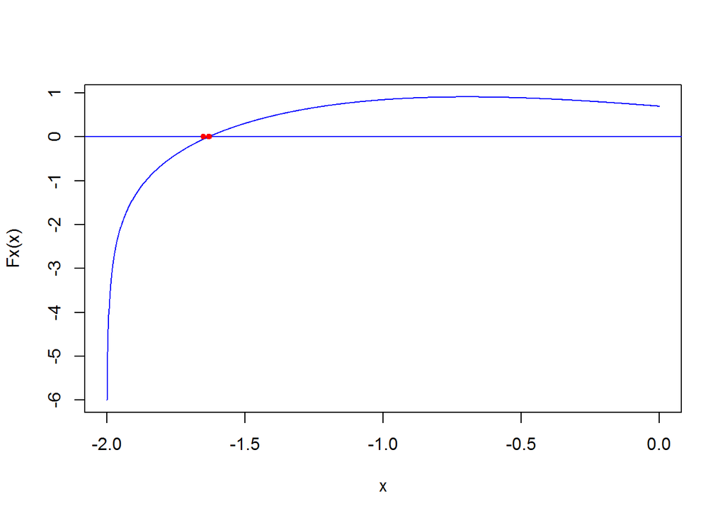

```
## X= -1.650187      E= 0.01821171
## X= -1.628789      E= 0.002665268
## X= -1.631368      E= 7.510581e-05
## X= -1.631444      E= 3.003488e-07
## X= -1.631444      E= 3.398911e-11
```

```r
# Metodo de secante
# Remueve todos los objetos creados
rm(list=ls())
Fx <- function(x) log(x+2)-sin(x)
F1x <- function(x) (1/(x+2))-cos(x)
# Halla la raiz de Fx
secante <- function(x0,x1) {
  x<-seq(-2,0,0.001)
  plot(x,Fx(x),type="l",col="blue")
  abline(h=0,col="blue")
  x<-(Fx(x1)*x0-Fx(x0)*x1)/(Fx(x1)-Fx(x0))
  error <-1
  while (error > 1.e-7) {
    x0<-x1
    x1<-x
    x<-(Fx(x1)*x0-Fx(x0)*x1)/(Fx(x1)-Fx(x0))
    if (Fx(x) == 0) break
    error<-abs(Fx(x)/F1x(x))
    points(rbind(c(x,0)),pch=19,cex=0.7,col="red")
    cat("X=",x,"\t","E=",error,"\n")
  }
}
secante(-1.99,-1.5)
```

2. Se usa el metodo Newton, con el intervalo de existencia previo usado en el problema de la secante. Sin embargo no es posible hallar ninguna aproximacion deseada , por lo que para saber si existe una raiz se usa el metodo de biseccion por siempre garantizar la convergencia y para confirmar el valor ya hallado.

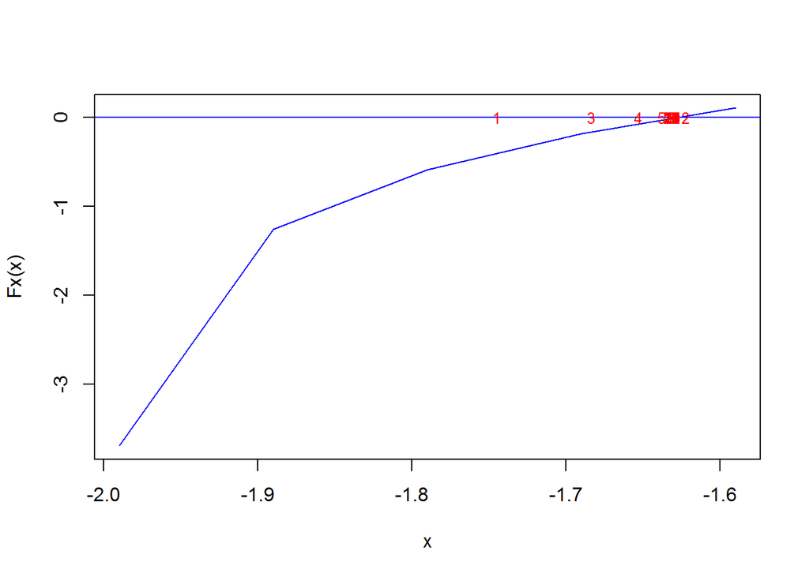

```
## X= -1.745    E= 0.245
## X= -1.6225   E= 0.1225
## X= -1.68375  E= 0.06125
## X= -1.653125     E= 0.030625
## X= -1.637813     E= 0.0153125
## X= -1.630156     E= 0.00765625
## X= -1.633984     E= 0.003828125
## X= -1.63207  E= 0.001914063
## X= -1.631113     E= 0.0009570313
## X= -1.631592     E= 0.0004785156
## X= -1.631353     E= 0.0002392578
## X= -1.631472     E= 0.0001196289
## X= -1.631412     E= 5.981445e-05
## X= -1.631442     E= 2.990723e-05
## X= -1.631457     E= 1.495361e-05
## X= -1.63145  E= 7.476807e-06
## X= -1.631446     E= 3.738403e-06
## X= -1.631444     E= 1.869202e-06
## X= -1.631443     E= 9.346008e-07
## X= -1.631444     E= 4.673004e-07
## X= -1.631443     E= 2.336502e-07
## X= -1.631444     E= 1.168251e-07
## X= -1.631444     E= 5.841255e-08
```

```r
# Remueve todos los objetos creados
rm(list=ls())
Fx <- function(x) log(x+2)-sin(x)
# Halla la raiz de Fx
biseccion <- function(a,b) {
  x<-seq(a,b,00.1)
  plot(x,Fx(x),type="l",col="blue")
  abline(h=0,col="blue")
  x<-b
  d<-(a+b)/2
  i<-0
  error<-abs(a-b)/2
  while (error > 1.e-7) {
    i<-i+1
    if (Fx(x) == 0) break
    if (Fx(x)*Fx(a) < 0) b <- x else {a <- x}
    d<-x
    x<-(a+b)/2
    #points(rbind(c(x,0)),pch=17,cex=0.7,col="red")
    text(x,0,i,cex=0.8,col="red")
    error<-abs(a-b)/2
    cat("X=",x,"\tE=",error,"\n")
  }
}
biseccion(-1.99,-1.5)
```

Ahora antes aplicar en los algoritmos, se corrobora el resultado, modificando el codigo para evaluar si la convergencia se acerca a 0:

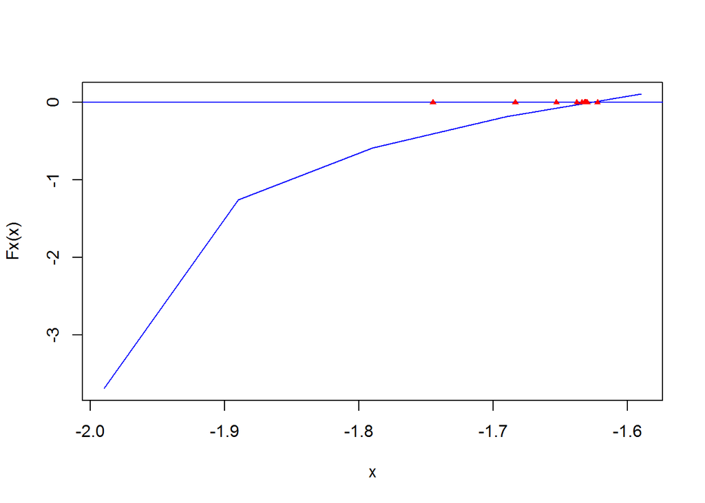

```
## X= -1.745    E= 0.245
## Evaluacion  -0.3816269
## Evaluacion Derivada  4.094893
##
## X= -1.6225   E= 0.1225
## Evaluacion  0.02447895
## Evaluacion Derivada  2.700687
##
## X= -1.68375  E= 0.06125
## Evaluacion  -0.1575947
## Evaluacion Derivada  3.274769
##
## X= -1.653125     E= 0.030625
## Evaluacion  -0.06217789
## Evaluacion Derivada  2.965119
##
## X= -1.637813     E= 0.0153125
## Evaluacion  -0.01783799
## Evaluacion Derivada  2.827967
##
## X= -1.630156     E= 0.00765625
## Evaluacion  0.003564057
## Evaluacion Derivada  2.76317
##
## X= -1.633984     E= 0.003828125
## Evaluacion  -0.007074956
## Evaluacion Derivada  2.79527
##
## X= -1.63207  E= 0.001914063
## Evaluacion  -0.001740089
## Evaluacion Derivada  2.779146
##
## X= -1.631113     E= 0.0009570313
## Evaluacion  0.0009158066
## Evaluacion Derivada  2.77114
##
## X= -1.631592     E= 0.0004785156
## Evaluacion  -0.0004111834
## Evaluacion Derivada  2.775138
##
```

[output cut: 37 more lines]

```
## Evaluacion  -1.821746e-07
## Evaluacion Derivada  2.7739
##
## X= -1.631443     E= 2.336502e-07
## Evaluacion  4.659474e-07
## Evaluacion Derivada  2.773898
##
## X= -1.631444     E= 1.168251e-07
## Evaluacion  1.418865e-07
## Evaluacion Derivada  2.773899
##
## X= -1.631444     E= 5.841255e-08
## Evaluacion  -2.014404e-08
## Evaluacion Derivada  2.773899
##
```

```r
# Remueve todos los objetos creados
rm(list=ls())
Fx <- function(x) log(x+2)-sin(x)
F1x <- function(x) (1/(x+2))-cos(x)
# Halla la raiz de Fx
biseccion <- function(a,b) {
  x<-seq(a,b,00.1)
  plot(x,Fx(x),type="l",col="blue")
  abline(h=0,col="blue")
  x<-b
  d<-(a+b)/2
  i<-0
  error<-abs(a-b)/2
  while (error > 1.e-7) {
    i<-i+1
    if (Fx(x) == 0) break
    if (Fx(x)*Fx(a) < 0) b <- x else {a <- x}
    d<-x
    x<-(a+b)/2
    points(rbind(c(x,0)),pch=17,cex=0.7,col="red")
    #text(x,0,i,cex=0.8,col="red")
    error<-abs(a-b)/2
    cat("X=",x,"\tE=",error,"\n")
    cat("Evaluacion ",Fx(x),"\n")
    cat("Evaluacion Derivada ",F1x(x),"\n","\n")
  }
}
biseccion(-1.99,-1.5)
```

Dado codigo concluimos que la raiz es valida puesto que se acerca cada vez mas a 0 y a su vez que la derivada de la funcion evaluada en la misma es diferente de 0 por lo que cumple con el intervalo local de convergencia de Newton. Sin embargo al graficar las funciones: f(x)

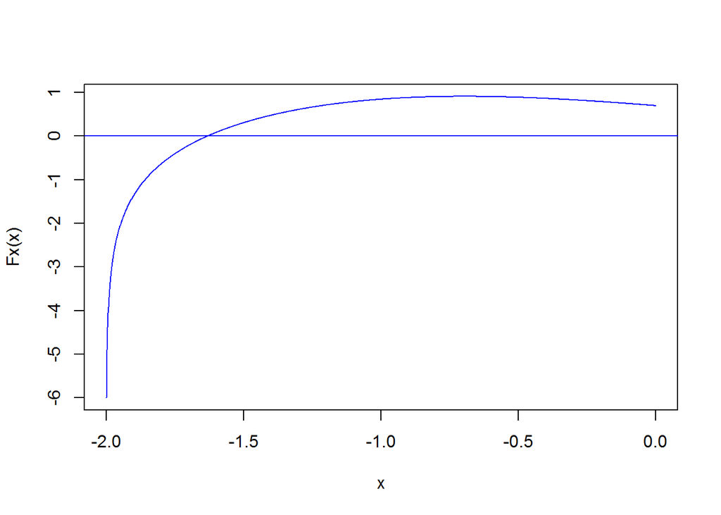

```r
Fx <- function(x) log(x+2)-sin(x)
x<-seq(-2,0,0.001)
plot(x,Fx(x),type="l",col="blue")
abline(h=0,col="blue")
```

f`(x)

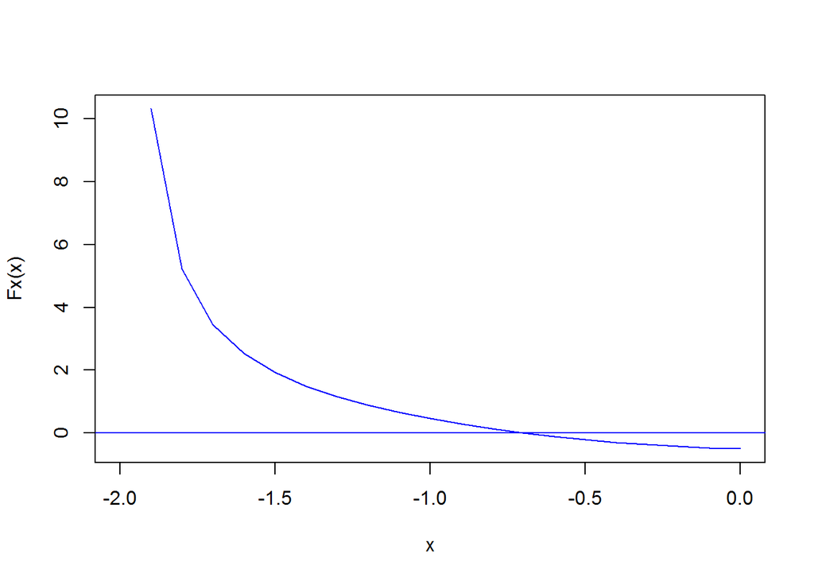

```r
Fx <- function(x) (1/(x+2))-cos(x)
x<-seq(-2,0,0.1)
plot(x,Fx(x),type="l",col="blue")
abline(h=0,col="blue")
```

f``(x)

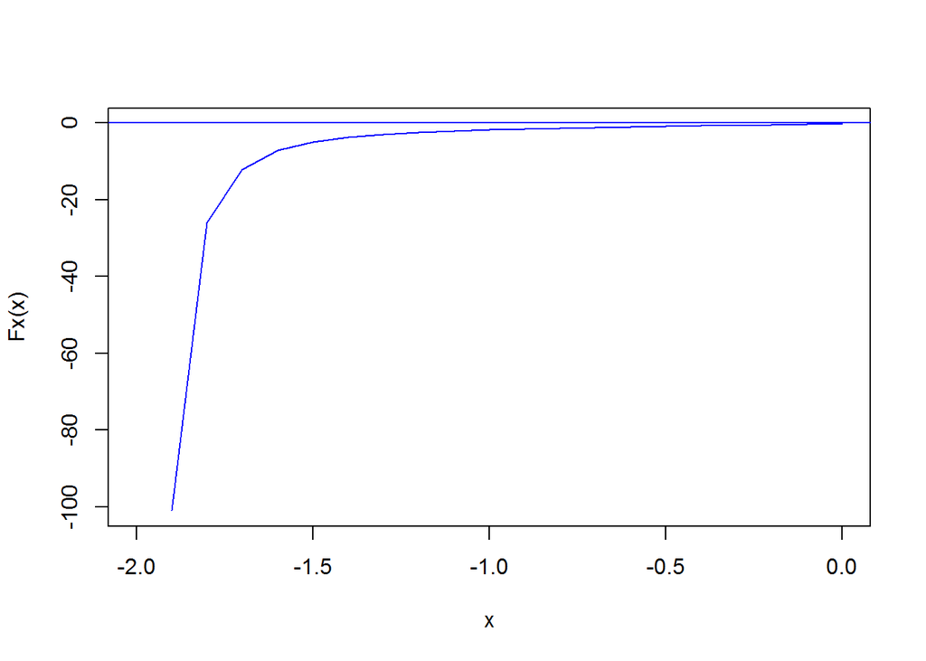

```r
Fx <- function(x) (-1/(x+2)^2)+sin(x)
x<-seq(-2,0,0.1)
plot(x,Fx(x),type="l",col="blue")
abline(h=0,col="blue")
```

Si se grafica en un rango considerable se obtiene:

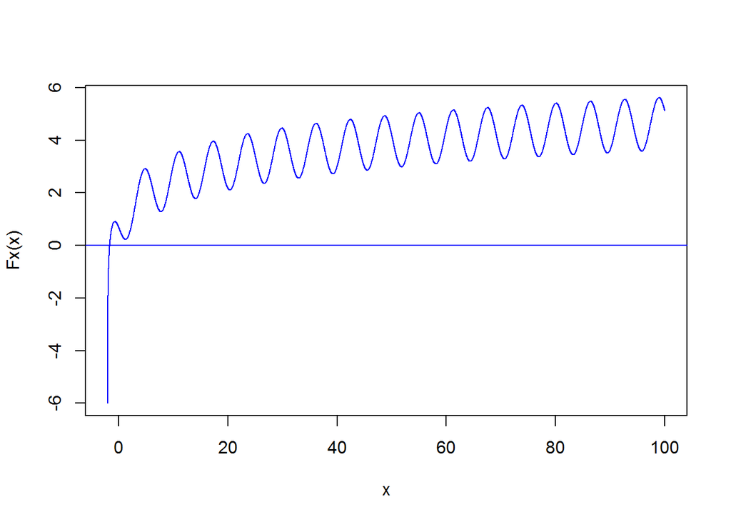

```r
# Metodo de Newton
rm(list=ls())
Fx <- function(x) log(x+2)-sin(x)
F1x <- function(x) (1/(x+2))-cos(x)
# Metodo de Newton
# Halla la raiz de
  x<-seq(-2,100,0.001)
  plot(x,Fx(x),type="l",col="blue")
  abline(h=0,col="blue")
```